# Abschlussprojekt

Du arbeitest als Data Scientist bei einer P-2-P-Plattform, die vor einem Jahr gegründet wurde. Nun wollt ihr euer Geschäft erweitern. Euer Team hat sich aufgeteilt und jeder Analyst hat einen Teilbereich der Daten. Deine Aufgabe ist es in einer *explorativen Datenanalyse* Insights für eure Plattform herauszufinden.

Euer Geschäftsmodell ist das Betreiben einer Plattform (crowd-investing) bei der sich Personen die eine Geschäftsidee haben, aber nicht das benötigte Geld, anmelden und für ihr Projekt innerhalb einer vorgegebenen Zeit Geld sammeln können. Auf der anderen Seite habt ihr Geldgeber, die gern ihr Geld in Projekte anlegen möchten und nach Investitionen suchen. Als Vermittler bringt eure Plattform also Geldnehmer und Geldgeber zusammen. Ihr verdient euer Geld mit einer Provision für jedes Projekt was auf eurer Plattform landet. Das Rückzahlungsrisiko wird über den Zinssatz abgebildet.

Deine Datenbasis ist die Historie eurer Plattform. Alle Projekte sind abgeschlossene Projekte, d.h. die Zeit, um für sein Projekt Geld zu sammeln ist abgelaufen. Euer Geschäftsmodell sieht es vor, dass die gesammelten Gelder ausgezahlt werden, auch wenn der Zielbetrag nicht erreicht wurde.

Dafür ist der Datensatz zunächst vorzubereiten. In die Bewertung geht zudem die Dokumentation mit ein. Für die Visualisierung sind **3 verschiedenartige Plots** zu benennen, die in die Bewertung eingehen sollen. Das bedeutet nicht, dass du nur 3 Plots ersellen darfst - ausschließlich für die Bewertung sind drei verschiedenartige Plots zu benennen! Weiterhin sollen es verschiedenartige Plots sein! Das bedeuted, ein Balkendiagramm und ein grouped Balkendiagramm sind am Ende des Tages Balkendiagramme. Im Abschlussprojekt zeigst du nicht, dass du eine Art von Plot in verschiedenen Varianten darstellen kannst, sondern, dass du verschiedene Plots kannst.

Vergiss dabei nicht die Erkenntnisse die aus jedem Plot gezogen werden können, zu notieren.

Die Dokumentation kann in englisch oder deutsch erfolgen.

Am Freitag erfolgt die Vorstellung der Plots innerhalb des Zeitrahmens von 5min - (+-1min) ist dabei ok.

Treff ist **Donnerstag um 14:30 Uhr** im Hauptraum. Da werden wir die Unterlagen in dokumentensichere Formate umwandeln. Das machen wir aber zusammen. Danach habt ihr bis 15:35 Uhr zeit, eure zu bewertenden Unterlagen in den Projektabgabeordner hochzuladen.

Der gesplittete Datensatz enthält folgende Spalten (inkl. Bedeutung):

```
- funded_amount ... mit Ablauf der "Crowding"zeit erhaltener Betrag/ ausgezahlter Betrag in USD
- loan_amount ... Zielbetrag (Betrag dem man für das Projekt erreichen wollte) in USD
- activity ... Unterkategory zu dem das Ziel des Crowdprojektes thematisch gehört
- sector ... Oberkategory in den das Crowdprojektes Thema fällt
- use ... Kurzbeschreibung wofür das Geld verwendet werden soll
- country_code ... Ländercode nach ISO Norm
- country ... Ländername nach ISO Norm
- region ... Region
- currency ... Währung in den der funded_amount dann ausgezahlt wurde
- term in months ... Dauer über die der Kredit ausgezahlt werden soll
- lender_count ...Darlehensgeber (also wieviele Personen Geld für das Projekt gegeben haben)
- borrower_genders ... Geschlecht und Anzahl der Darlehensnehmer, also diejenigen die das Crowdprojekt initiiert haben
- repayment interval ... vertraglich vereinbarte Rückzahlungsmodalitäten/-rhythmus
```

## Graphs to be evaluated

### Countries least funded

### Sectors least funded

### Mode of payment

### Outstanding

# P 2 P Plattform Data Analysis

## Import Libraries

```python
# importing necessary libraries
import pandas as pd
import numpy as np
#import necessary libraries
import matplotlib.pyplot as plt
import squarify # pip install squarify
import seaborn as sns
```

## Reading Data

```python
# Reading 2 rows of data 1, to know the separator with /n
df1 = pd.read_csv("your_part1.csv", sep="/n", engine='python', nrows=2)
df1
# Separator is ,
```

|  | , funded_amount, loan_amount, activity, sector, use, country_code, country, region, currency, term_in_months, lender_count, borrower_genders, repayment_interval |
| --- | --- |
| 0 | 0,300.0,300.0,Fruits & Vegetables,Food,"To buy... |
| 1 | 1,575.0,575.0,Rickshaw,Transportation,to repai... |

## Data Preprocessing

```python
# Read the complete data1

df1 = pd.read_csv("your_part1.csv", sep=",", index_col=0)
df1
```

|  | funded_amount | loan_amount | activity | sector | use | country_code | country | region | currency | term_in_months | lender_count | borrower_genders | repayment_interval |
| --- | --- | --- | --- | --- | --- | --- | --- | --- | --- | --- | --- | --- | --- |
| 0 | 300.0 | 300.0 | Fruits & Vegetables | Food | To buy seasonal, fresh fruits to sell. | PK | Pakistan | Lahore | PKR | 12.0 | 12 | female | irregular |
| 1 | 575.0 | 575.0 | Rickshaw | Transportation | to repair and maintain the auto rickshaw used ... | PK | Pakistan | Lahore | PKR | 11.0 | 14 | female, female | irregular |
| 2 | 150.0 | 150.0 | Transportation | Transportation | To repair their old cycle-van and buy another ... | IN | India | Maynaguri | INR | 43.0 | 6 | female | bullet |
| 3 | 200.0 | 200.0 | Embroidery | Arts | to purchase an embroidery machine and a variet... | PK | Pakistan | Lahore | PKR | 11.0 | 8 | female | irregular |
| 4 | 400.0 | 400.0 | Milk Sales | Food | to purchase one buffalo. | PK | Pakistan | Abdul Hakeem | PKR | 14.0 | 16 | female | monthly |
| ... | ... | ... | ... | ... | ... | ... | ... | ... | ... | ... | ... | ... | ... |
| 334995 | 7125.0 | 7125.0 | Plastics Sales | Retail | to stock up with a dozen plastic tubs and buck... | CD | The Democratic Republic of the Congo | Goma, North Kivu province | USD | 6.0 | 15 | female, female, female, female, female, female... | irregular |
| 334996 | 125.0 | 125.0 | Home Appliances | Personal Use | to buy a water filter to provide safe drinking... | KH | Cambodia | Phnom Penh | KHR | 8.0 | 5 | male, male, male | monthly |
| 334997 | 925.0 | 925.0 | Cattle | Agriculture | to increase his herd to get more milk and prov... | TJ | Tajikistan | Khuroson | TJS | 14.0 | 28 | male | monthly |
| 334998 | 175.0 | 175.0 | General Store | Retail | to buy additional items to sell, like beverage... | PH | Philippines | Palo, Leyte | PHP | 8.0 | 6 | female | irregular |
| 334999 | 150.0 | 150.0 | Food Production/Sales | Food | to buy sticky rice and sugar. | PH | Philippines | Jagna, Bohol | PHP | 8.0 | 5 | female | irregular |

335000 rows × 13 columns

```python
# Reading 2 rows of data 2, to know the separator with /n
df2 = pd.read_csv("your_part2.csv", sep="/n", engine='python', nrows=2)
df2
# Separator is #
```

|  | # funded_amount# loan_amount# activity# sector# use# country_code# country# region# currency# term_in_months# lender_count# borrower_genders# repayment_interval |
| --- | --- |
| 0 | 0#175.0#175.0#Liquor Store / Off-License#Food#... |
| 1 | 1#325.0#325.0#Livestock#Agriculture#to buy 3 z... |

```python
#Read the complete data2
df2 = pd.read_csv("your_part2.csv", sep="#", index_col=0)
df2
```

|  | funded_amount | loan_amount | activity | sector | use | country_code | country | region | currency | term_in_months | lender_count | borrower_genders | repayment_interval |
| --- | --- | --- | --- | --- | --- | --- | --- | --- | --- | --- | --- | --- | --- |
| 0 | 175.0 | 175.0 | Liquor Store / Off-License | Food | to purchase additional stock of coconut wine t... | PH | Philippines | Palo, Leyte | PHP | 8.0 | 6 | female | irregular |
| 1 | 325.0 | 325.0 | Livestock | Agriculture | to buy 3 zebus and food to fatten them up. | MG | Madagascar | Antsirabe | MGA | 12.0 | 13 | female | monthly |
| 2 | 550.0 | 550.0 | Food Stall | Food | to buy ingredients for her food-vending busine... | PH | Philippines | Cordova, Cebu | PHP | 5.0 | 6 | female | irregular |
| 3 | 1300.0 | 1300.0 | Cattle | Agriculture | to buy one head of cattle. | EG | Egypt | Baniswef | EGP | 14.0 | 50 | male | monthly |
| 4 | 900.0 | 900.0 | Consumer Goods | Personal Use | to buy consumer goods amongst others. | PE | Peru | Urubamba - Urubamba - Cusco | PEN | 6.0 | 1 | female | irregular |
| ... | ... | ... | ... | ... | ... | ... | ... | ... | ... | ... | ... | ... | ... |
| 336200 | 0.0 | 25.0 | Livestock | Agriculture | [True, u'para compara: cemento, arenya y ladri... | PY | Paraguay | Concepción | USD | 13.0 | 0 | female | monthly |
| 336201 | 25.0 | 25.0 | Livestock | Agriculture | [True, u'to start a turducken farm.'] - this l... | KE | Kenya | NaN | KES | 13.0 | 1 | female | monthly |
| 336202 | 0.0 | 25.0 | Games | Entertainment | NaN | KE | Kenya | NaN | KES | 13.0 | 0 | NaN | monthly |
| 336203 | 0.0 | 25.0 | Livestock | Agriculture | [True, u'to start a turducken farm.'] - this l... | KE | Kenya | NaN | KES | 13.0 | 0 | female | monthly |
| 336204 | 0.0 | 25.0 | Livestock | Agriculture | [True, u'to start a turducken farm.'] - this l... | KE | Kenya | NaN | KES | 13.0 | 0 | female | monthly |

336205 rows × 13 columns

```python
# check if the length of both the data are same
len(df1)==len(df2)
```

```
False
```

```python
# They cannot be merged
#Check if both the dataframes have equal number of columns
#Check the column names
```

```python
df1.shape
```

```
(335000, 13)
```

```python
df1.columns
```

```
Index([' funded_amount', ' loan_amount', ' activity', ' sector', ' use',
       ' country_code', ' country', ' region', ' currency', ' term_in_months',
       ' lender_count', ' borrower_genders', ' repayment_interval'],
      dtype='object')
```

```python
df2.shape
```

```
(336205, 13)
```

```python
df2.columns
```

```
Index([' funded_amount', ' loan_amount', ' activity', ' sector', ' use',
       ' country_code', ' country', ' region', ' currency', ' term_in_months',
       ' lender_count', ' borrower_genders', ' repayment_interval'],
      dtype='object')
```

```python
# Both have 13 columns and same column names
# Hence concat is the best way to combine the 2 dfs
# axis = 0 to concatenate vertically
df3 = pd.concat([df1,df2], axis=0)
df3
```

|  | funded_amount | loan_amount | activity | sector | use | country_code | country | region | currency | term_in_months | lender_count | borrower_genders | repayment_interval |
| --- | --- | --- | --- | --- | --- | --- | --- | --- | --- | --- | --- | --- | --- |
| 0 | 300.0 | 300.0 | Fruits & Vegetables | Food | To buy seasonal, fresh fruits to sell. | PK | Pakistan | Lahore | PKR | 12.0 | 12 | female | irregular |
| 1 | 575.0 | 575.0 | Rickshaw | Transportation | to repair and maintain the auto rickshaw used ... | PK | Pakistan | Lahore | PKR | 11.0 | 14 | female, female | irregular |
| 2 | 150.0 | 150.0 | Transportation | Transportation | To repair their old cycle-van and buy another ... | IN | India | Maynaguri | INR | 43.0 | 6 | female | bullet |
| 3 | 200.0 | 200.0 | Embroidery | Arts | to purchase an embroidery machine and a variet... | PK | Pakistan | Lahore | PKR | 11.0 | 8 | female | irregular |
| 4 | 400.0 | 400.0 | Milk Sales | Food | to purchase one buffalo. | PK | Pakistan | Abdul Hakeem | PKR | 14.0 | 16 | female | monthly |
| ... | ... | ... | ... | ... | ... | ... | ... | ... | ... | ... | ... | ... | ... |
| 336200 | 0.0 | 25.0 | Livestock | Agriculture | [True, u'para compara: cemento, arenya y ladri... | PY | Paraguay | Concepción | USD | 13.0 | 0 | female | monthly |
| 336201 | 25.0 | 25.0 | Livestock | Agriculture | [True, u'to start a turducken farm.'] - this l... | KE | Kenya | NaN | KES | 13.0 | 1 | female | monthly |
| 336202 | 0.0 | 25.0 | Games | Entertainment | NaN | KE | Kenya | NaN | KES | 13.0 | 0 | NaN | monthly |
| 336203 | 0.0 | 25.0 | Livestock | Agriculture | [True, u'to start a turducken farm.'] - this l... | KE | Kenya | NaN | KES | 13.0 | 0 | female | monthly |
| 336204 | 0.0 | 25.0 | Livestock | Agriculture | [True, u'to start a turducken farm.'] - this l... | KE | Kenya | NaN | KES | 13.0 | 0 | female | monthly |

671205 rows × 13 columns

```python
df3.shape
# 336205 + 335000 = 671205 number of rows now
# column number remains 13 which is right
```

```
(671205, 13)
```

### Check for duplicates

```python
df4=df3.columns
```

```python
# consider duplicate when all the values in all the columns are same
df3.loc[df3[df4].duplicated(keep=False)==True,:]
```

|  | funded_amount | loan_amount | activity | sector | use | country_code | country | region | currency | term_in_months | lender_count | borrower_genders | repayment_interval |
| --- | --- | --- | --- | --- | --- | --- | --- | --- | --- | --- | --- | --- | --- |
| 327 | 275.0 | 275.0 | Farming | Agriculture | to buy fertilizers and other farm supplies. | PH | Philippines | Brookes Point, Palawan | PHP | 8.0 | 8 | female | irregular |
| 392 | 100.0 | 100.0 | Home Energy | Personal Use | to buy a solar lamp. | SV | El Salvador | NaN | USD | 14.0 | 4 | male | monthly |
| 405 | 100.0 | 100.0 | Home Energy | Personal Use | to buy a solar-powered lamp. | SV | El Salvador | NaN | USD | 14.0 | 4 | male | monthly |
| 498 | 100.0 | 100.0 | Home Energy | Personal Use | to buy a solar-powered lamp. | SV | El Salvador | NaN | USD | 14.0 | 4 | male | monthly |
| 606 | 100.0 | 100.0 | Home Energy | Personal Use | to buy a solar-powered lamp. | SV | El Salvador | NaN | USD | 14.0 | 4 | male | monthly |
| ... | ... | ... | ... | ... | ... | ... | ... | ... | ... | ... | ... | ... | ... |
| 336200 | 0.0 | 25.0 | Livestock | Agriculture | [True, u'para compara: cemento, arenya y ladri... | PY | Paraguay | Concepción | USD | 13.0 | 0 | female | monthly |
| 336201 | 25.0 | 25.0 | Livestock | Agriculture | [True, u'to start a turducken farm.'] - this l... | KE | Kenya | NaN | KES | 13.0 | 1 | female | monthly |
| 336202 | 0.0 | 25.0 | Games | Entertainment | NaN | KE | Kenya | NaN | KES | 13.0 | 0 | NaN | monthly |
| 336203 | 0.0 | 25.0 | Livestock | Agriculture | [True, u'to start a turducken farm.'] - this l... | KE | Kenya | NaN | KES | 13.0 | 0 | female | monthly |
| 336204 | 0.0 | 25.0 | Livestock | Agriculture | [True, u'to start a turducken farm.'] - this l... | KE | Kenya | NaN | KES | 13.0 | 0 | female | monthly |

34633 rows × 13 columns

```python
#drop duplicated rows keeping the first one
df4=df3.drop_duplicates(keep='first')
df4
```

|  | funded_amount | loan_amount | activity | sector | use | country_code | country | region | currency | term_in_months | lender_count | borrower_genders | repayment_interval |
| --- | --- | --- | --- | --- | --- | --- | --- | --- | --- | --- | --- | --- | --- |
| 0 | 300.0 | 300.0 | Fruits & Vegetables | Food | To buy seasonal, fresh fruits to sell. | PK | Pakistan | Lahore | PKR | 12.0 | 12 | female | irregular |
| 1 | 575.0 | 575.0 | Rickshaw | Transportation | to repair and maintain the auto rickshaw used ... | PK | Pakistan | Lahore | PKR | 11.0 | 14 | female, female | irregular |
| 2 | 150.0 | 150.0 | Transportation | Transportation | To repair their old cycle-van and buy another ... | IN | India | Maynaguri | INR | 43.0 | 6 | female | bullet |
| 3 | 200.0 | 200.0 | Embroidery | Arts | to purchase an embroidery machine and a variet... | PK | Pakistan | Lahore | PKR | 11.0 | 8 | female | irregular |
| 4 | 400.0 | 400.0 | Milk Sales | Food | to purchase one buffalo. | PK | Pakistan | Abdul Hakeem | PKR | 14.0 | 16 | female | monthly |
| ... | ... | ... | ... | ... | ... | ... | ... | ... | ... | ... | ... | ... | ... |
| 336179 | 0.0 | 25.0 | Livestock | Agriculture | [True, u'para compara: cemento, arenya y ladri... | PY | Paraguay | Concepción | USD | 13.0 | 0 | female | monthly |
| 336181 | 0.0 | 25.0 | Livestock | Agriculture | Reviewed loan use in english. | PK | Pakistan | Attock | PKR | 13.0 | 0 | female | monthly |
| 336182 | 0.0 | 125.0 | Livestock | Agriculture | Pretend the flagged issue was addressed by KC. | MX | Mexico | Iztacalco | MXN | 13.0 | 0 | female, female | monthly |
| 336184 | 0.0 | 875.0 | Livestock | Agriculture | Translated loan use to english. | BO | Bolivia | La Paz | BOB | 13.0 | 0 | female, female | monthly |
| 336188 | 0.0 | 250.0 | Livestock | Agriculture | Reviewed loan use in english. | GH | Ghana | Dansoman | GHS | 13.0 | 0 | female | monthly |

646833 rows × 13 columns

```python
# confirm if all the duplicates have been dropped
df5=df4.columns
df5
```

```
Index([' funded_amount', ' loan_amount', ' activity', ' sector', ' use',
       ' country_code', ' country', ' region', ' currency', ' term_in_months',
       ' lender_count', ' borrower_genders', ' repayment_interval'],
      dtype='object')
```

```python
#df4 is our dataframe without duplicats
df4.loc[df4[df5].duplicated(keep=False)==True,:]
#confirmed
# out of 671205 only 646833 remain
```

|  | funded_amount | loan_amount | activity | sector | use | country_code | country | region | currency | term_in_months | lender_count | borrower_genders | repayment_interval |
| --- | --- | --- | --- | --- | --- | --- | --- | --- | --- | --- | --- | --- | --- |

```python
# reset index
df4.reset_index(drop=True, inplace=True)
df4
```

|  | funded_amount | loan_amount | activity | sector | use | country_code | country | region | currency | term_in_months | lender_count | borrower_genders | repayment_interval |
| --- | --- | --- | --- | --- | --- | --- | --- | --- | --- | --- | --- | --- | --- |
| 0 | 300.0 | 300.0 | Fruits & Vegetables | Food | To buy seasonal, fresh fruits to sell. | PK | Pakistan | Lahore | PKR | 12.0 | 12 | female | irregular |
| 1 | 575.0 | 575.0 | Rickshaw | Transportation | to repair and maintain the auto rickshaw used ... | PK | Pakistan | Lahore | PKR | 11.0 | 14 | female, female | irregular |
| 2 | 150.0 | 150.0 | Transportation | Transportation | To repair their old cycle-van and buy another ... | IN | India | Maynaguri | INR | 43.0 | 6 | female | bullet |
| 3 | 200.0 | 200.0 | Embroidery | Arts | to purchase an embroidery machine and a variet... | PK | Pakistan | Lahore | PKR | 11.0 | 8 | female | irregular |
| 4 | 400.0 | 400.0 | Milk Sales | Food | to purchase one buffalo. | PK | Pakistan | Abdul Hakeem | PKR | 14.0 | 16 | female | monthly |
| ... | ... | ... | ... | ... | ... | ... | ... | ... | ... | ... | ... | ... | ... |
| 646828 | 0.0 | 25.0 | Livestock | Agriculture | [True, u'para compara: cemento, arenya y ladri... | PY | Paraguay | Concepción | USD | 13.0 | 0 | female | monthly |
| 646829 | 0.0 | 25.0 | Livestock | Agriculture | Reviewed loan use in english. | PK | Pakistan | Attock | PKR | 13.0 | 0 | female | monthly |
| 646830 | 0.0 | 125.0 | Livestock | Agriculture | Pretend the flagged issue was addressed by KC. | MX | Mexico | Iztacalco | MXN | 13.0 | 0 | female, female | monthly |
| 646831 | 0.0 | 875.0 | Livestock | Agriculture | Translated loan use to english. | BO | Bolivia | La Paz | BOB | 13.0 | 0 | female, female | monthly |
| 646832 | 0.0 | 250.0 | Livestock | Agriculture | Reviewed loan use in english. | GH | Ghana | Dansoman | GHS | 13.0 | 0 | female | monthly |

646833 rows × 13 columns

### Removing spaces from column names

```python
df4.columns = df4.columns.str.replace(' ', '')
df4.columns
```

```
Index(['funded_amount', 'loan_amount', 'activity', 'sector', 'use',
       'country_code', 'country', 'region', 'currency', 'term_in_months',
       'lender_count', 'borrower_genders', 'repayment_interval'],
      dtype='object')
```

```python
df4.shape
```

```
(646833, 13)
```

### Missing data

```python
df4
```

|  | funded_amount | loan_amount | activity | sector | use | country_code | country | region | currency | term_in_months | lender_count | borrower_genders | repayment_interval |
| --- | --- | --- | --- | --- | --- | --- | --- | --- | --- | --- | --- | --- | --- |
| 0 | 300.0 | 300.0 | Fruits & Vegetables | Food | To buy seasonal, fresh fruits to sell. | PK | Pakistan | Lahore | PKR | 12.0 | 12 | female | irregular |
| 1 | 575.0 | 575.0 | Rickshaw | Transportation | to repair and maintain the auto rickshaw used ... | PK | Pakistan | Lahore | PKR | 11.0 | 14 | female, female | irregular |
| 2 | 150.0 | 150.0 | Transportation | Transportation | To repair their old cycle-van and buy another ... | IN | India | Maynaguri | INR | 43.0 | 6 | female | bullet |
| 3 | 200.0 | 200.0 | Embroidery | Arts | to purchase an embroidery machine and a variet... | PK | Pakistan | Lahore | PKR | 11.0 | 8 | female | irregular |
| 4 | 400.0 | 400.0 | Milk Sales | Food | to purchase one buffalo. | PK | Pakistan | Abdul Hakeem | PKR | 14.0 | 16 | female | monthly |
| ... | ... | ... | ... | ... | ... | ... | ... | ... | ... | ... | ... | ... | ... |
| 646828 | 0.0 | 25.0 | Livestock | Agriculture | [True, u'para compara: cemento, arenya y ladri... | PY | Paraguay | Concepción | USD | 13.0 | 0 | female | monthly |
| 646829 | 0.0 | 25.0 | Livestock | Agriculture | Reviewed loan use in english. | PK | Pakistan | Attock | PKR | 13.0 | 0 | female | monthly |
| 646830 | 0.0 | 125.0 | Livestock | Agriculture | Pretend the flagged issue was addressed by KC. | MX | Mexico | Iztacalco | MXN | 13.0 | 0 | female, female | monthly |
| 646831 | 0.0 | 875.0 | Livestock | Agriculture | Translated loan use to english. | BO | Bolivia | La Paz | BOB | 13.0 | 0 | female, female | monthly |
| 646832 | 0.0 | 250.0 | Livestock | Agriculture | Reviewed loan use in english. | GH | Ghana | Dansoman | GHS | 13.0 | 0 | female | monthly |

646833 rows × 13 columns

```python
df4.dtypes
# all the data types look appropriate
```

```
funded_amount         float64
loan_amount           float64
activity               object
sector                 object
use                    object
country_code           object
country                object
region                 object
currency               object
term_in_months        float64
lender_count            int64
borrower_genders       object
repayment_interval     object
dtype: object
```

```python
df4.isnull().sum()
# check how many nulls in all the columns
# col region has has the maximum nulls
# country_code has only 8 nulls
# use has 3899
# borrower_genders has 3888
```

```
funded_amount             0
loan_amount               0
activity                  0
sector                    0
use                    3899
country_code              8
country                   0
region                56163
currency                  0
term_in_months            0
lender_count              0
borrower_genders       3888
repayment_interval        0
dtype: int64
```

```python
# Percentage of null values
round(df4.isnull().sum()/len(df4) * 100,2)
```

```
funded_amount         0.00
loan_amount           0.00
activity              0.00
sector                0.00
use                   0.60
country_code          0.00
country               0.00
region                8.68
currency              0.00
term_in_months        0.00
lender_count          0.00
borrower_genders      0.60
repayment_interval    0.00
dtype: float64
```

#### Missing data in Country_code

```python
# Number of Countries
df4.loc[:,'country'].nunique()
```

```
87
```

```python
# see which countries exist
df4.loc[:,'country'].unique()
```

```
array(['Pakistan', 'India', 'Kenya', 'Nicaragua', 'El Salvador',
       'Tanzania', 'Philippines', 'Peru', 'Senegal', 'Cambodia',
       'Liberia', 'Vietnam', 'Iraq', 'Honduras', 'Palestine', 'Mongolia',
       'United States', 'Mali', 'Colombia', 'Tajikistan', 'Guatemala',
       'Ecuador', 'Bolivia', 'Yemen', 'Ghana', 'Sierra Leone', 'Haiti',
       'Chile', 'Jordan', 'Uganda', 'Burundi', 'Burkina Faso',
       'Timor-Leste', 'Indonesia', 'Georgia', 'Ukraine', 'Kosovo',
       'Albania', 'The Democratic Republic of the Congo', 'Costa Rica',
       'Somalia', 'Zimbabwe', 'Cameroon', 'Turkey', 'Azerbaijan',
       'Dominican Republic', 'Brazil', 'Mexico', 'Kyrgyzstan', 'Armenia',
       'Paraguay', 'Lebanon', 'Samoa', 'Israel', 'Rwanda', 'Zambia',
       'Nepal', 'Congo', 'Mozambique', 'South Africa', 'Togo', 'Benin',
       'Belize', 'Suriname', 'Thailand', 'Nigeria', 'Mauritania',
       'Vanuatu', 'Panama', 'Virgin Islands',
       'Saint Vincent and the Grenadines',
       "Lao People's Democratic Republic", 'Malawi', 'Myanmar (Burma)',
       'Moldova', 'South Sudan', 'Solomon Islands', 'China', 'Egypt',
       'Guam', 'Afghanistan', 'Madagascar', 'Namibia', 'Puerto Rico',
       'Lesotho', "Cote D'Ivoire", 'Bhutan'], dtype=object)
```

```python
df4.loc[:,'country_code'].nunique()
# out of 87 countries, 86 have codes
```

```
86
```

```python
# List of codes
df4.loc[:,'country_code'].unique()
```

```
array(['PK', 'IN', 'KE', 'NI', 'SV', 'TZ', 'PH', 'PE', 'SN', 'KH', 'LR',
       'VN', 'IQ', 'HN', 'PS', 'MN', 'US', 'ML', 'CO', 'TJ', 'GT', 'EC',
       'BO', 'YE', 'GH', 'SL', 'HT', 'CL', 'JO', 'UG', 'BI', 'BF', 'TL',
       'ID', 'GE', 'UA', 'XK', 'AL', 'CD', 'CR', 'SO', 'ZW', 'CM', 'TR',
       'AZ', 'DO', 'BR', 'MX', 'KG', 'AM', 'PY', 'LB', 'WS', 'IL', 'RW',
       'ZM', 'NP', 'CG', 'MZ', 'ZA', 'TG', 'BJ', 'BZ', 'SR', 'TH', 'NG',
       'MR', 'VU', 'PA', 'VI', 'VC', 'LA', 'MW', 'MM', 'MD', 'SS', 'SB',
       'CN', 'EG', 'GU', 'AF', 'MG', nan, 'PR', 'LS', 'CI', 'BT'],
      dtype=object)
```

```python
# check which countries have nulls for country code
df5=df4.loc[df4.country_code.isnull(),:]
df5
# all the nulls in country code belongs to country Namibia
```

|  | funded_amount | loan_amount | activity | sector | use | country_code | country | region | currency | term_in_months | lender_count | borrower_genders | repayment_interval |
| --- | --- | --- | --- | --- | --- | --- | --- | --- | --- | --- | --- | --- | --- |
| 198369 | 4150.0 | 4150.0 | Wholesale | Wholesale | To purchase lighting products for sale to loca... | NaN | Namibia | EEnhana | NAD | 6.0 | 162 | female | bullet |
| 198646 | 4150.0 | 4150.0 | Wholesale | Wholesale | To purchase lighting products for sale to loca... | NaN | Namibia | Rundu | NAD | 6.0 | 159 | male | bullet |
| 337622 | 3325.0 | 3325.0 | Wholesale | Wholesale | To purchase lighting products for sale to loca... | NaN | Namibia | EEnhana | NAD | 7.0 | 120 | female | bullet |
| 343771 | 3325.0 | 3325.0 | Wholesale | Wholesale | To purchase lighting products for sale to loca... | NaN | Namibia | Rundu | NAD | 7.0 | 126 | male | bullet |
| 411637 | 3325.0 | 3325.0 | Wholesale | Wholesale | To purchase lighting products for sale to loca... | NaN | Namibia | EEnhana | NAD | 7.0 | 118 | female | bullet |
| 411895 | 4000.0 | 4000.0 | Wholesale | Wholesale | purchase solar lighting products for sale to l... | NaN | Namibia | Rundu | NAD | 7.0 | 150 | male | bullet |
| 474672 | 5100.0 | 5100.0 | Renewable Energy Products | Retail | to pay for stock of solar lights and cell phon... | NaN | Namibia | Katima Mulilo | NAD | 7.0 | 183 | male | bullet |
| 475099 | 5000.0 | 5000.0 | Wholesale | Wholesale | to maintain a stock of solar lights and cell p... | NaN | Namibia | Oshakati | NAD | 7.0 | 183 | female | bullet |

```python
# check if there are country_code values in other rows for Namibia
df5=df4.loc[df4.country=='Namibia',:]
df5
# we have 8 rows with country Namibia and all have nulls for country_code
```

|  | funded_amount | loan_amount | activity | sector | use | country_code | country | region | currency | term_in_months | lender_count | borrower_genders | repayment_interval |
| --- | --- | --- | --- | --- | --- | --- | --- | --- | --- | --- | --- | --- | --- |
| 198369 | 4150.0 | 4150.0 | Wholesale | Wholesale | To purchase lighting products for sale to loca... | NaN | Namibia | EEnhana | NAD | 6.0 | 162 | female | bullet |
| 198646 | 4150.0 | 4150.0 | Wholesale | Wholesale | To purchase lighting products for sale to loca... | NaN | Namibia | Rundu | NAD | 6.0 | 159 | male | bullet |
| 337622 | 3325.0 | 3325.0 | Wholesale | Wholesale | To purchase lighting products for sale to loca... | NaN | Namibia | EEnhana | NAD | 7.0 | 120 | female | bullet |
| 343771 | 3325.0 | 3325.0 | Wholesale | Wholesale | To purchase lighting products for sale to loca... | NaN | Namibia | Rundu | NAD | 7.0 | 126 | male | bullet |
| 411637 | 3325.0 | 3325.0 | Wholesale | Wholesale | To purchase lighting products for sale to loca... | NaN | Namibia | EEnhana | NAD | 7.0 | 118 | female | bullet |
| 411895 | 4000.0 | 4000.0 | Wholesale | Wholesale | purchase solar lighting products for sale to l... | NaN | Namibia | Rundu | NAD | 7.0 | 150 | male | bullet |
| 474672 | 5100.0 | 5100.0 | Renewable Energy Products | Retail | to pay for stock of solar lights and cell phon... | NaN | Namibia | Katima Mulilo | NAD | 7.0 | 183 | male | bullet |
| 475099 | 5000.0 | 5000.0 | Wholesale | Wholesale | to maintain a stock of solar lights and cell p... | NaN | Namibia | Oshakati | NAD | 7.0 | 183 | female | bullet |

```python
#replace nans with a ISO country_code NA
df4['country_code'] = df4['country_code'].replace(np.nan, 'NA')
```

```python
#check if Namibia has a country code NB now
df5=df4.loc[df4.country=='Namibia',:]
df5
```

|  | funded_amount | loan_amount | activity | sector | use | country_code | country | region | currency | term_in_months | lender_count | borrower_genders | repayment_interval |
| --- | --- | --- | --- | --- | --- | --- | --- | --- | --- | --- | --- | --- | --- |
| 198369 | 4150.0 | 4150.0 | Wholesale | Wholesale | To purchase lighting products for sale to loca... | NA | Namibia | EEnhana | NAD | 6.0 | 162 | female | bullet |
| 198646 | 4150.0 | 4150.0 | Wholesale | Wholesale | To purchase lighting products for sale to loca... | NA | Namibia | Rundu | NAD | 6.0 | 159 | male | bullet |
| 337622 | 3325.0 | 3325.0 | Wholesale | Wholesale | To purchase lighting products for sale to loca... | NA | Namibia | EEnhana | NAD | 7.0 | 120 | female | bullet |
| 343771 | 3325.0 | 3325.0 | Wholesale | Wholesale | To purchase lighting products for sale to loca... | NA | Namibia | Rundu | NAD | 7.0 | 126 | male | bullet |
| 411637 | 3325.0 | 3325.0 | Wholesale | Wholesale | To purchase lighting products for sale to loca... | NA | Namibia | EEnhana | NAD | 7.0 | 118 | female | bullet |
| 411895 | 4000.0 | 4000.0 | Wholesale | Wholesale | purchase solar lighting products for sale to l... | NA | Namibia | Rundu | NAD | 7.0 | 150 | male | bullet |
| 474672 | 5100.0 | 5100.0 | Renewable Energy Products | Retail | to pay for stock of solar lights and cell phon... | NA | Namibia | Katima Mulilo | NAD | 7.0 | 183 | male | bullet |
| 475099 | 5000.0 | 5000.0 | Wholesale | Wholesale | to maintain a stock of solar lights and cell p... | NA | Namibia | Oshakati | NAD | 7.0 | 183 | female | bullet |

#### Missing Data in Borrower_genders

```python
# Research on borrower_genders  it has  3888 null values
df4.loc[:,'borrower_genders'].nunique()
#it has 11298 unique values
```

```
11298
```

```python
df6=df4.loc[df4.borrower_genders.isnull(),]
df6
```

|  | funded_amount | loan_amount | activity | sector | use | country_code | country | region | currency | term_in_months | lender_count | borrower_genders | repayment_interval |
| --- | --- | --- | --- | --- | --- | --- | --- | --- | --- | --- | --- | --- | --- |
| 140 | 2975.0 | 2975.0 | Food Production/Sales | Food | NaN | TZ | Tanzania | NaN | TZS | 10.0 | 110 | NaN | monthly |
| 145 | 1200.0 | 1200.0 | Personal Expenses | Personal Use | NaN | PE | Peru | NaN | PEN | 20.0 | 44 | NaN | monthly |
| 170 | 4250.0 | 4250.0 | Catering | Food | NaN | TZ | Tanzania | NaN | TZS | 10.0 | 116 | NaN | monthly |
| 412 | 2350.0 | 2350.0 | Beauty Salon | Services | NaN | TZ | Tanzania | NaN | TZS | 10.0 | 75 | NaN | monthly |
| 414 | 725.0 | 725.0 | Agriculture | Agriculture | NaN | SV | El Salvador | NaN | USD | 20.0 | 19 | NaN | monthly |
| ... | ... | ... | ... | ... | ... | ... | ... | ... | ... | ... | ... | ... | ... |
| 636081 | 5625.0 | 10000.0 | Weaving | Arts | NaN | BT | Bhutan | NaN | USD | 14.0 | 210 | NaN | irregular |
| 637157 | 1975.0 | 1975.0 | Home Energy | Personal Use | NaN | PS | Palestine | NaN | USD | 27.0 | 39 | NaN | monthly |
| 637995 | 800.0 | 1600.0 | Furniture Making | Manufacturing | NaN | HT | Haiti | NaN | HTG | 13.0 | 27 | NaN | irregular |
| 646812 | 0.0 | 25.0 | Livestock | Agriculture | NaN | KE | Kenya | NaN | KES | 13.0 | 0 | NaN | monthly |
| 646826 | 0.0 | 25.0 | Games | Entertainment | NaN | KE | Kenya | NaN | KES | 13.0 | 0 | NaN | monthly |

3888 rows × 13 columns

```python
#since I do not want to lose important data in other columns, I will not delete these rows.
#instead I will replace them to 'unknown'
df4["borrower_genders"] = df4["borrower_genders"].replace(np.nan, 'unknown')
```

```python
df6=df4.loc[df4.borrower_genders.isnull(),]
df6
# now it has no null values
```

|  | funded_amount | loan_amount | activity | sector | use | country_code | country | region | currency | term_in_months | lender_count | borrower_genders | repayment_interval |
| --- | --- | --- | --- | --- | --- | --- | --- | --- | --- | --- | --- | --- | --- |

```python
df4.loc[df4['borrower_genders']=='unknown',['borrower_genders']]
```

|  | borrower_genders |
| --- | --- |
| 140 | unknown |
| 145 | unknown |
| 170 | unknown |
| 412 | unknown |
| 414 | unknown |
| ... | ... |
| 636081 | unknown |
| 637157 | unknown |
| 637995 | unknown |
| 646812 | unknown |
| 646826 | unknown |

3888 rows × 1 columns

```python
df4.isnull().sum()
```

```
funded_amount             0
loan_amount               0
activity                  0
sector                    0
use                    3899
country_code              0
country                   0
region                56163
currency                  0
term_in_months            0
lender_count              0
borrower_genders          0
repayment_interval        0
dtype: int64
```

```python
#Next research column 'use'
# just like borrower_genders, I do not want to lose important data in other columns,
#I will not delete these rows with nan values for 'use'
#instaed replace these values with 'notspecified'
df4['use'] = df4['use'].replace(np.nan, 'notspecified')
```

```python
#confirm if there are no nulls in 'use'
df7=df4.loc[df4.use.isnull(),]
df7
```

|  | funded_amount | loan_amount | activity | sector | use | country_code | country | region | currency | term_in_months | lender_count | borrower_genders | repayment_interval |
| --- | --- | --- | --- | --- | --- | --- | --- | --- | --- | --- | --- | --- | --- |

```python
df4.loc[df4['use']=='notspecified',['use']]
```

|  | use |
| --- | --- |
| 140 | notspecified |
| 145 | notspecified |
| 170 | notspecified |
| 412 | notspecified |
| 414 | notspecified |
| ... | ... |
| 636081 | notspecified |
| 637157 | notspecified |
| 637995 | notspecified |
| 646812 | notspecified |
| 646826 | notspecified |

3899 rows × 1 columns

#### Missing Data in Region

```python
df4.isnull().sum()
#now only region has nulls
```

```
funded_amount             0
loan_amount               0
activity                  0
sector                    0
use                       0
country_code              0
country                   0
region                56163
currency                  0
term_in_months            0
lender_count              0
borrower_genders          0
repayment_interval        0
dtype: int64
```

```python
round(df4.isnull().sum()/len(df4) * 100,2)
# 8.68 %
```

```
funded_amount         0.00
loan_amount           0.00
activity              0.00
sector                0.00
use                   0.00
country_code          0.00
country               0.00
region                8.68
currency              0.00
term_in_months        0.00
lender_count          0.00
borrower_genders      0.00
repayment_interval    0.00
dtype: float64
```

```python
#replace nulls with np.nan so that it does not interfere with the calculations/visualisation later
df4.loc[df4.region.isnull()==True,'region']=np.nan
```

## Working with the final data to generate insights

### Modifying Final data to add Columns

```python
# add a cloumn to find the amount not funded
df4["balance_tobe_funded"] =  df4["loan_amount"]-df4["funded_amount"]
df4
```

|  | funded_amount | loan_amount | activity | sector | use | country_code | country | region | currency | term_in_months | lender_count | borrower_genders | repayment_interval | balance_tobe_funded |
| --- | --- | --- | --- | --- | --- | --- | --- | --- | --- | --- | --- | --- | --- | --- |
| 0 | 300.0 | 300.0 | Fruits & Vegetables | Food | To buy seasonal, fresh fruits to sell. | PK | Pakistan | Lahore | PKR | 12.0 | 12 | female | irregular | 0.0 |
| 1 | 575.0 | 575.0 | Rickshaw | Transportation | to repair and maintain the auto rickshaw used ... | PK | Pakistan | Lahore | PKR | 11.0 | 14 | female, female | irregular | 0.0 |
| 2 | 150.0 | 150.0 | Transportation | Transportation | To repair their old cycle-van and buy another ... | IN | India | Maynaguri | INR | 43.0 | 6 | female | bullet | 0.0 |
| 3 | 200.0 | 200.0 | Embroidery | Arts | to purchase an embroidery machine and a variet... | PK | Pakistan | Lahore | PKR | 11.0 | 8 | female | irregular | 0.0 |
| 4 | 400.0 | 400.0 | Milk Sales | Food | to purchase one buffalo. | PK | Pakistan | Abdul Hakeem | PKR | 14.0 | 16 | female | monthly | 0.0 |
| ... | ... | ... | ... | ... | ... | ... | ... | ... | ... | ... | ... | ... | ... | ... |
| 646828 | 0.0 | 25.0 | Livestock | Agriculture | [True, u'para compara: cemento, arenya y ladri... | PY | Paraguay | Concepción | USD | 13.0 | 0 | female | monthly | 25.0 |
| 646829 | 0.0 | 25.0 | Livestock | Agriculture | Reviewed loan use in english. | PK | Pakistan | Attock | PKR | 13.0 | 0 | female | monthly | 25.0 |
| 646830 | 0.0 | 125.0 | Livestock | Agriculture | Pretend the flagged issue was addressed by KC. | MX | Mexico | Iztacalco | MXN | 13.0 | 0 | female, female | monthly | 125.0 |
| 646831 | 0.0 | 875.0 | Livestock | Agriculture | Translated loan use to english. | BO | Bolivia | La Paz | BOB | 13.0 | 0 | female, female | monthly | 875.0 |
| 646832 | 0.0 | 250.0 | Livestock | Agriculture | Reviewed loan use in english. | GH | Ghana | Dansoman | GHS | 13.0 | 0 | female | monthly | 250.0 |

646833 rows × 14 columns

```python
# check how many projects are not funded completely
df5=df4.loc[df4.balance_tobe_funded>0,]
df5
#df5 is my projects not funded completely
```

|  | funded_amount | loan_amount | activity | sector | use | country_code | country | region | currency | term_in_months | lender_count | borrower_genders | repayment_interval | balance_tobe_funded |
| --- | --- | --- | --- | --- | --- | --- | --- | --- | --- | --- | --- | --- | --- | --- |
| 87 | 4275.0 | 5000.0 | Personal Housing Expenses | Housing | to pave the ground and repair the ceiling, to ... | PS | Palestine | jenin | USD | 39.0 | 58 | male | monthly | 725.0 |
| 112 | 1925.0 | 2400.0 | Electronics Repair | Services | to pay the annual rent for his shop | IQ | Iraq | NaN | USD | 15.0 | 41 | male | monthly | 475.0 |
| 186 | 2625.0 | 3000.0 | Grocery Store | Food | to pay the annual rent on his grocery store an... | IQ | Iraq | NaN | USD | 15.0 | 72 | male | monthly | 375.0 |
| 309 | 2750.0 | 3000.0 | Grocery Store | Food | to install a new floor in his grocery store an... | IQ | Iraq | NaN | USD | 15.0 | 44 | male | monthly | 250.0 |
| 313 | 1300.0 | 3000.0 | Clothing | Clothing | to buy shoes and clothes to sell. | PS | Palestine | jenin | USD | 27.0 | 35 | female | monthly | 1700.0 |
| ... | ... | ... | ... | ... | ... | ... | ... | ... | ... | ... | ... | ... | ... | ... |
| 646828 | 0.0 | 25.0 | Livestock | Agriculture | [True, u'para compara: cemento, arenya y ladri... | PY | Paraguay | Concepción | USD | 13.0 | 0 | female | monthly | 25.0 |
| 646829 | 0.0 | 25.0 | Livestock | Agriculture | Reviewed loan use in english. | PK | Pakistan | Attock | PKR | 13.0 | 0 | female | monthly | 25.0 |
| 646830 | 0.0 | 125.0 | Livestock | Agriculture | Pretend the flagged issue was addressed by KC. | MX | Mexico | Iztacalco | MXN | 13.0 | 0 | female, female | monthly | 125.0 |
| 646831 | 0.0 | 875.0 | Livestock | Agriculture | Translated loan use to english. | BO | Bolivia | La Paz | BOB | 13.0 | 0 | female, female | monthly | 875.0 |
| 646832 | 0.0 | 250.0 | Livestock | Agriculture | Reviewed loan use in english. | GH | Ghana | Dansoman | GHS | 13.0 | 0 | female | monthly | 250.0 |

48035 rows × 14 columns

### Outliers

#### Funded_amount

```python
y1=list(df4.loc[df4.funded_amount>40000,'funded_amount'])
```

```python
x1=df4.loc[df4.funded_amount>40000,'funded_amount'].index
```

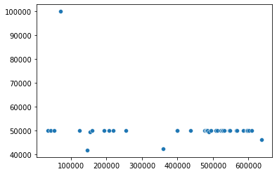

```python
sns.scatterplot(x=x1,
                y=y1)
```

```python
#Outlier in this column is a project (69745) in haiti
# Funded Completely

df4.loc[(df4.funded_amount>90000),:]
```

|  | funded_amount | loan_amount | activity | sector | use | country_code | country | region | currency | term_in_months | lender_count | borrower_genders | repayment_interval | balance_tobe_funded |
| --- | --- | --- | --- | --- | --- | --- | --- | --- | --- | --- | --- | --- | --- | --- |
| 69745 | 100000.0 | 100000.0 | Agriculture | Agriculture | create more than 300 jobs for women and farmer... | HT | Haiti | Les Cayes | USD | 75.0 | 2986 | female | irregular | 0.0 |

#### term_in_months

```python
y2=list(df4.loc[df4.term_in_months>120,'term_in_months'])
```

```python
x2=df4.loc[df4.term_in_months>120,'term_in_months'].index
```

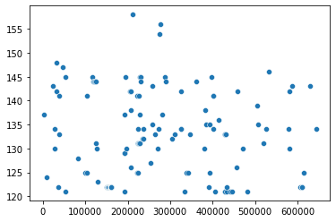

```python
sns.scatterplot(x=x2,
                y=y2)
```

```python
df4.loc[(df4.term_in_months>150),:]
# 3 projects from Dominican Republic have term_in_months > 150
```

|  | funded_amount | loan_amount | activity | sector | use | country_code | country | region | currency | term_in_months | lender_count | borrower_genders | repayment_interval | balance_tobe_funded |
| --- | --- | --- | --- | --- | --- | --- | --- | --- | --- | --- | --- | --- | --- | --- |
| 211552 | 6725.0 | 6725.0 | Higher education costs | Education | To cover educational expenses for pursuing a M... | DO | Dominican Republic | San Francisco de Macoris | DOP | 158.0 | 244 | female | irregular | 0.0 |
| 275435 | 6675.0 | 6675.0 | Higher education costs | Education | to pay for higher education expenses. | DO | Dominican Republic | Santo Domingo | DOP | 154.0 | 207 | male | irregular | 0.0 |
| 276338 | 8900.0 | 8900.0 | Higher education costs | Education | to pay further education costs. | DO | Dominican Republic | Santo Domingo | DOP | 156.0 | 253 | female | irregular | 0.0 |

#### lender_count

```python
y3=list(df4.loc[df4.lender_count>1200,'lender_count'])
```

```python
x3=df4.loc[df4.lender_count>1200,'lender_count'].index
```

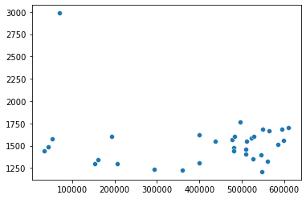

```python
sns.scatterplot(x=x3,
                y=y3)
```

```python
df4.loc[(df4.term_in_months>150),:]
```

|  | funded_amount | loan_amount | activity | sector | use | country_code | country | region | currency | term_in_months | lender_count | borrower_genders | repayment_interval | balance_tobe_funded |
| --- | --- | --- | --- | --- | --- | --- | --- | --- | --- | --- | --- | --- | --- | --- |
| 211552 | 6725.0 | 6725.0 | Higher education costs | Education | To cover educational expenses for pursuing a M... | DO | Dominican Republic | San Francisco de Macoris | DOP | 158.0 | 244 | female | irregular | 0.0 |
| 275435 | 6675.0 | 6675.0 | Higher education costs | Education | to pay for higher education expenses. | DO | Dominican Republic | Santo Domingo | DOP | 154.0 | 207 | male | irregular | 0.0 |
| 276338 | 8900.0 | 8900.0 | Higher education costs | Education | to pay further education costs. | DO | Dominican Republic | Santo Domingo | DOP | 156.0 | 253 | female | irregular | 0.0 |

#### Loan Amount

```python
df4.loc[(df4.lender_count>2000),:]
# Biggest project
```

|  | funded_amount | loan_amount | activity | sector | use | country_code | country | region | currency | term_in_months | lender_count | borrower_genders | repayment_interval | balance_tobe_funded |
| --- | --- | --- | --- | --- | --- | --- | --- | --- | --- | --- | --- | --- | --- | --- |
| 69745 | 100000.0 | 100000.0 | Agriculture | Agriculture | create more than 300 jobs for women and farmer... | HT | Haiti | Les Cayes | USD | 75.0 | 2986 | female | irregular | 0.0 |

```python
y5=list(df4.loc[df4.loan_amount>40000,'loan_amount'])
```

```python
x5=df4.loc[df4.loan_amount>40000,'loan_amount'].index
```

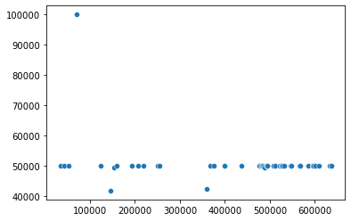

```python
sns.scatterplot(x=x5,
                y=y5)
```

#### Risk Projects

```python
y4=list(df4.loc[df4.balance_tobe_funded>10000,'balance_tobe_funded'])
```

```python
x4=df4.loc[df4.balance_tobe_funded>10000,'balance_tobe_funded'].index
```

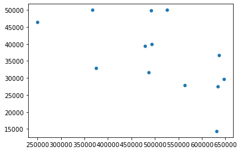

```python
sns.scatterplot(x=x4,
                y=y4)
```

```python
df4.loc[(df4.balance_tobe_funded>40000)& (df4.funded_amount<300),:]
# 2 projects below have zero investors and high Loan Amount
```

|  | funded_amount | loan_amount | activity | sector | use | country_code | country | region | currency | term_in_months | lender_count | borrower_genders | repayment_interval | balance_tobe_funded |
| --- | --- | --- | --- | --- | --- | --- | --- | --- | --- | --- | --- | --- | --- | --- |
| 367300 | 0.0 | 50000.0 | Taxi | Transportation | notspecified | MX | Mexico | NaN | USD | 17.0 | 0 | unknown | irregular | 50000.0 |
| 492394 | 200.0 | 50000.0 | Food Production/Sales | Food | notspecified | PE | Peru | NaN | USD | 60.0 | 7 | unknown | irregular | 49800.0 |
| 525338 | 0.0 | 50000.0 | Goods Distribution | Wholesale | notspecified | HT | Haiti | NaN | USD | 14.0 | 0 | unknown | irregular | 50000.0 |

### Insight Countries

```python
# How many projects are not funded country wise
df_country1= df5.groupby('country', as_index=False).size()
df_country1
```

|  | country | size |
| --- | --- | --- |
| 0 | Albania | 229 |
| 1 | Armenia | 1824 |
| 2 | Azerbaijan | 307 |
| 3 | Benin | 5 |
| 4 | Bhutan | 1 |
| ... | ... | ... |
| 67 | Vietnam | 959 |
| 68 | Virgin Islands | 2 |
| 69 | Yemen | 162 |
| 70 | Zambia | 60 |
| 71 | Zimbabwe | 66 |

72 rows × 2 columns

```python
# Total projects under each country
df_country2=df4.groupby('country', as_index=False).size()
df_country2.sort_values('size', ascending=True, inplace=True)
df_country2.reset_index(drop=True, inplace=True)
df_country2
```

|  | country | size |
| --- | --- | --- |
| 0 | Mauritania | 1 |
| 1 | Guam | 1 |
| 2 | Cote D'Ivoire | 1 |
| 3 | Afghanistan | 2 |
| 4 | Bhutan | 2 |
| ... | ... | ... |
| 82 | Pakistan | 26475 |
| 83 | Cambodia | 27067 |
| 84 | El Salvador | 39845 |
| 85 | Kenya | 73554 |
| 86 | Philippines | 154323 |

87 rows × 2 columns

```python
df_countryfinal = pd.merge(df_country1,df_country2, how="outer",on='country')
df_countryfinal['size_x'] = df_countryfinal['size_x'].fillna(0)
df_countryfinal["Percentage_not_funded"]=round((df_countryfinal['size_x']/df_countryfinal['size_y'])*100,1)
df_countryfinal.sort_values('Percentage_not_funded', ascending=False, inplace=True)
df_countryfinal=df_countryfinal.loc[df_countryfinal['Percentage_not_funded']>0,:]
df_countryfinal.reset_index(drop=True, inplace=True)
df_countryfinal
#size_x number of projects not funded completely
# size_y Total number of projects
```

|  | country | size_x | size_y | Percentage_not_funded |
| --- | --- | --- | --- | --- |
| 0 | Virgin Islands | 2.0 | 2 | 100.0 |
| 1 | Guam | 1.0 | 1 | 100.0 |
| 2 | Bhutan | 1.0 | 2 | 50.0 |
| 3 | United States | 2200.0 | 6092 | 36.1 |
| 4 | Puerto Rico | 16.0 | 68 | 23.5 |
| ... | ... | ... | ... | ... |
| 67 | Brazil | 2.0 | 284 | 0.7 |
| 68 | China | 1.0 | 134 | 0.7 |
| 69 | Thailand | 1.0 | 170 | 0.6 |
| 70 | Lao People's Democratic Republic | 3.0 | 1417 | 0.2 |
| 71 | Turkey | 1.0 | 1688 | 0.1 |

72 rows × 4 columns

#### Plot1 Countries

```python
#import necessary libraries
import matplotlib.pyplot as plt
import squarify # pip install squarify
import seaborn as sns
```

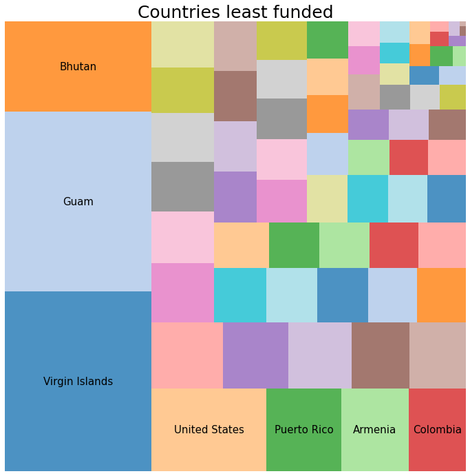

```python
fig, ax = plt.subplots(1, figsize = (12,12))

squarify.plot(sizes=df_countryfinal['Percentage_not_funded'],
              label=df_countryfinal['country'][:7],
              alpha=.8,
              text_kwargs={'fontsize': 15},
              color=sns.color_palette("tab20", len(
                                        df_countryfinal['country'].value_counts())),)

plt.axis('off')
ax.set_title('Countries least funded', fontsize=25)



plt.show()
```

### Insight Sectors

```python
# to know what percentage of projects in each sector are not funded
df_sector= df5.groupby('sector', as_index=False).size()
df_sector
```

|  | sector | size |
| --- | --- | --- |
| 0 | Agriculture | 13624 |
| 1 | Arts | 200 |
| 2 | Clothing | 2982 |
| 3 | Construction | 332 |
| 4 | Education | 771 |
| 5 | Entertainment | 104 |
| 6 | Food | 8059 |
| 7 | Health | 614 |
| 8 | Housing | 3998 |
| 9 | Manufacturing | 46 |
| 10 | Personal Use | 1420 |
| 11 | Retail | 10264 |
| 12 | Services | 3878 |
| 13 | Transportation | 1722 |
| 14 | Wholesale | 21 |

```python
# Total projects under each sector
df_sector2=df4.groupby('sector', as_index=False).size()
df_sector2
```

|  | sector | size |
| --- | --- | --- |
| 0 | Agriculture | 174624 |
| 1 | Arts | 11938 |
| 2 | Clothing | 32554 |
| 3 | Construction | 6263 |
| 4 | Education | 30128 |
| 5 | Entertainment | 829 |
| 6 | Food | 135359 |
| 7 | Health | 9190 |
| 8 | Housing | 30155 |
| 9 | Manufacturing | 6204 |
| 10 | Personal Use | 25533 |
| 11 | Retail | 123186 |
| 12 | Services | 44844 |
| 13 | Transportation | 15392 |
| 14 | Wholesale | 634 |

```python
# to know the percentage
df_sectorfinal = df_sector.merge(df_sector2, on='sector', how="inner")
df_sectorfinal
# size_x is number of projects not funded
# size_y is total number of projects under each section
df_sectorfinal["Percentage_not_funded"]=round((df_sectorfinal['size_x']/df_sectorfinal['size_y'])*100,1)
df_sectorfinal.sort_values('Percentage_not_funded', ascending=False, inplace=True)
df_sectorfinal
```

|  | sector | size_x | size_y | Percentage_not_funded |
| --- | --- | --- | --- | --- |
| 8 | Housing | 3998 | 30155 | 13.3 |
| 5 | Entertainment | 104 | 829 | 12.5 |
| 13 | Transportation | 1722 | 15392 | 11.2 |
| 2 | Clothing | 2982 | 32554 | 9.2 |
| 12 | Services | 3878 | 44844 | 8.6 |
| 11 | Retail | 10264 | 123186 | 8.3 |
| 0 | Agriculture | 13624 | 174624 | 7.8 |
| 7 | Health | 614 | 9190 | 6.7 |
| 6 | Food | 8059 | 135359 | 6.0 |
| 10 | Personal Use | 1420 | 25533 | 5.6 |
| 3 | Construction | 332 | 6263 | 5.3 |
| 14 | Wholesale | 21 | 634 | 3.3 |
| 4 | Education | 771 | 30128 | 2.6 |
| 1 | Arts | 200 | 11938 | 1.7 |
| 9 | Manufacturing | 46 | 6204 | 0.7 |

```python
df_sector=df_sectorfinal.loc[:,['sector','Percentage_not_funded']]
df_sector.reset_index(drop=True, inplace=True)
df_sector=df_sector.head(5)
```

#### Plot2 Sectors

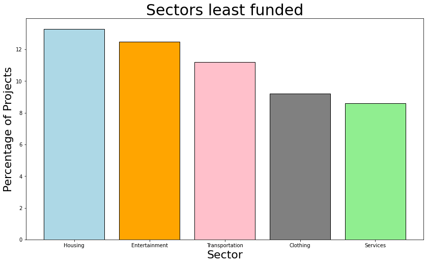

```python
# Platz für deine Visualisierung

# Schritt 1&2: Figuren-&Axenobject erstellen

fig, ax = plt.subplots()
fig.set_figheight(8)
fig.set_figwidth(14)

# Schritt 3: Plot erstellen

ax.bar(x=df_sector.sector,
       height=df_sector.iloc[:,1],
       color=['lightblue','orange','pink','grey','lightgreen'],
       edgecolor=['black','black','black','black','black','black'])


ax.set_title('Sectors least funded', fontsize=30)
ax.set_xlabel('Sector', fontsize=22)
ax.set_ylabel('Percentage of Projects', fontsize=22)

plt.rc('xtick', labelsize=15)
plt.rc('ytick', labelsize=15)


plt.show()
```

### Insight Payment Interval

```python
df_paymentmode= df4.groupby('repayment_interval', as_index=False).size()
df_paymentmode.sort_values('size', ascending=False, inplace=True)
df_paymentmode
```

|  | repayment_interval | size |
| --- | --- | --- |
| 2 | monthly | 330448 |
| 1 | irregular | 250051 |
| 0 | bullet | 65736 |
| 3 | weekly | 598 |

```python
df_paymentmode.describe()
```

|  | size |
| --- | --- |
| count | 4.00000 |
| mean | 161708.25000 |
| std | 154320.80237 |
| min | 598.00000 |
| 25% | 49451.50000 |
| 50% | 157893.50000 |
| 75% | 270150.25000 |
| max | 330448.00000 |

#### Plot3 Payment Interval

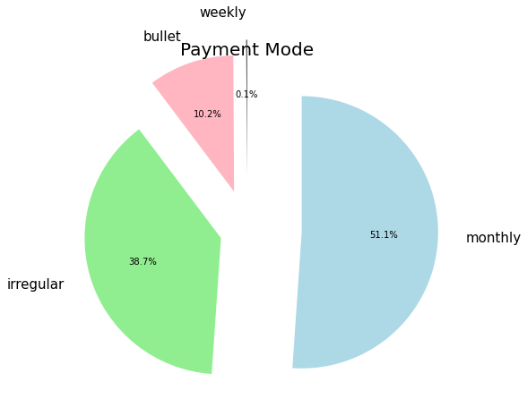

```python
formatierung = '%1.1f%%'
color = ['lightblue', 'lightgreen','lightpink','black']
label = ["monthly", "irregular","bullet","weekly"]

# figuren und achsenobjekt erstellen

fig, ax = plt.subplots()
slice_to_explode = (0.4, 0.2,0.3,0.4)
fig.set_figheight(7)
fig.set_figwidth(10)



ax.pie(x=df_paymentmode['size'],
       labels=label,
       colors=color,
       autopct=formatierung,
       pctdistance=0.6,
       labeldistance=1.2,
       startangle=90.0,
       counterclock=False,
       explode=slice_to_explode


      )


ax.set_title('Payment Mode', fontsize=20)

plt.show()


# bild speichern

fig = ax.get_figure()
fig.savefig("Payment Mode.png")
```

```python
import seaborn as sns
```

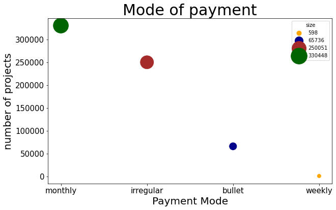

```python
fig, ax = plt.subplots(figsize=(10, 6))

sns.scatterplot(x = df_paymentmode['repayment_interval'],
                y = df_paymentmode['size'],
                size = df_paymentmode['size'],
                sizes=(80, 1000),
                legend="full",
                hue = df_paymentmode['size'],
                palette=["orange", "darkblue", "brown", "darkgreen"])

plt.xlabel("Payment Mode", fontsize=20)
plt.ylabel("number of projects",fontsize=20)

ax.set_title('Mode of payment', fontsize=30)
```

### Insights Currency

```python
df_currency= df4.groupby('currency', as_index=False).size()
df_currency.sort_values('size', ascending=False, inplace=True)
df_currency
```

|  | currency | size |
| --- | --- | --- |
| 42 | PHP | 154322 |
| 56 | USD | 105034 |
| 23 | KES | 73099 |
| 43 | PKR | 26474 |
| 9 | COP | 21950 |
| ... | ... | ... |
| 61 | XCD | 16 |
| 37 | NAD | 8 |
| 7 | CLP | 8 |
| 58 | VUV | 4 |
| 66 | ZWD | 2 |

67 rows × 2 columns

```python
df_currency= df4.groupby('currency', as_index=False).size()
df_currency.sort_values('size', ascending=False, inplace=True)
df_currency
```

|  | currency | size |
| --- | --- | --- |
| 42 | PHP | 154322 |
| 56 | USD | 105034 |
| 23 | KES | 73099 |
| 43 | PKR | 26474 |
| 9 | COP | 21950 |
| ... | ... | ... |
| 61 | XCD | 16 |
| 37 | NAD | 8 |
| 7 | CLP | 8 |
| 58 | VUV | 4 |
| 66 | ZWD | 2 |

67 rows × 2 columns

```python
df_currency1 = df4.groupby('currency').agg({'loan_amount':'sum'})
df_currency1
```

| currency | loan_amount |
| --- | --- |
| ALL | 2616500.0 |
| AMD | 7816825.0 |
| AZN | 2885150.0 |
| BIF | 2667850.0 |
| BOB | 17678850.0 |
| ... | ... |
| XOF | 20975100.0 |
| YER | 1879950.0 |
| ZAR | 531275.0 |
| ZMW | 1128075.0 |
| ZWD | 50.0 |

67 rows × 1 columns

```python
df_currency2 = df4.groupby('currency').agg({'funded_amount':'sum'})
df_currency2
```

| currency | funded_amount |
| --- | --- |
| ALL | 2440000.0 |
| AMD | 6582800.0 |
| AZN | 2696025.0 |
| BIF | 2558550.0 |
| BOB | 16350975.0 |
| ... | ... |
| XOF | 20000575.0 |
| YER | 1784075.0 |
| ZAR | 531275.0 |
| ZMW | 1074975.0 |
| ZWD | 50.0 |

67 rows × 1 columns

```python
df_currencyfinal = df_currency1.merge(df_currency2, on='currency', how="inner")
df_currencyfinal
```

| currency | loan_amount | funded_amount |
| --- | --- | --- |
| ALL | 2616500.0 | 2440000.0 |
| AMD | 7816825.0 | 6582800.0 |
| AZN | 2885150.0 | 2696025.0 |
| BIF | 2667850.0 | 2558550.0 |
| BOB | 17678850.0 | 16350975.0 |
| ... | ... | ... |
| XOF | 20975100.0 | 20000575.0 |
| YER | 1879950.0 | 1784075.0 |
| ZAR | 531275.0 | 531275.0 |
| ZMW | 1128075.0 | 1074975.0 |
| ZWD | 50.0 | 50.0 |

67 rows × 2 columns

```python
df_currencyfinal["Outstanding"]=df_currencyfinal["loan_amount"]-df_currencyfinal["funded_amount"]
df_currencyfinal
#round((df_sectorfinal['size_x']/df_sectorfinal['size_y'])*100,1)
```

| currency | loan_amount | funded_amount | Outstanding |
| --- | --- | --- | --- |
| ALL | 2616500.0 | 2440000.0 | 176500.0 |
| AMD | 7816825.0 | 6582800.0 | 1234025.0 |
| AZN | 2885150.0 | 2696025.0 | 189125.0 |
| BIF | 2667850.0 | 2558550.0 | 109300.0 |
| BOB | 17678850.0 | 16350975.0 | 1327875.0 |
| ... | ... | ... | ... |
| XOF | 20975100.0 | 20000575.0 | 974525.0 |
| YER | 1879950.0 | 1784075.0 | 95875.0 |
| ZAR | 531275.0 | 531275.0 | 0.0 |
| ZMW | 1128075.0 | 1074975.0 | 53100.0 |
| ZWD | 50.0 | 50.0 | 0.0 |

67 rows × 3 columns

```python
df_currencyfinal=df_currencyfinal.loc[df_currencyfinal['Outstanding']>0,:]
df_currencyfinal.sort_values('Outstanding', ascending=False, inplace=True)
df_currencyfinal
```

| currency | loan_amount | funded_amount | Outstanding |
| --- | --- | --- | --- |
| USD | 146023375.0 | 130053035.0 | 15970340.0 |
| KES | 32796100.0 | 30554955.0 | 2241145.0 |
| COP | 14331950.0 | 12390125.0 | 1941825.0 |
| BOB | 17678850.0 | 16350975.0 | 1327875.0 |
| AMD | 7816825.0 | 6582800.0 | 1234025.0 |
| VND | 14154350.0 | 12928975.0 | 1225375.0 |
| UGX | 14989225.0 | 13820525.0 | 1168700.0 |
| RWF | 16220175.0 | 15079475.0 | 1140700.0 |
| TJS | 12345000.0 | 11253050.0 | 1091950.0 |
| XOF | 20975100.0 | 20000575.0 | 974525.0 |
| KHR | 13397800.0 | 12472150.0 | 925650.0 |
| PHP | 54014950.0 | 53149650.0 | 865300.0 |
| PKR | 13114625.0 | 12293375.0 | 821250.0 |
| WST | 6284100.0 | 5634350.0 | 649750.0 |
| GTQ | 11220750.0 | 10744950.0 | 475800.0 |
| NIO | 6731950.0 | 6279750.0 | 452200.0 |
| KGS | 6731450.0 | 6309200.0 | 422250.0 |
| HNL | 5975675.0 | 5603625.0 | 372050.0 |
| TZS | 6412725.0 | 6105425.0 | 307300.0 |
| PEN | 28938325.0 | 28655150.0 | 283175.0 |
| IDR | 4402300.0 | 4121050.0 | 281250.0 |
| INR | 6630125.0 | 6370550.0 | 259575.0 |
| NGN | 1556025.0 | 1303150.0 | 252875.0 |
| JOD | 4682350.0 | 4435725.0 | 246625.0 |
| MXN | 9212500.0 | 8976125.0 | 236375.0 |
| SLL | 4143100.0 | 3923625.0 | 219475.0 |
| PYG | 29618000.0 | 29401700.0 | 216300.0 |
| MMK | 3212300.0 | 3005850.0 | 206450.0 |
| AZN | 2885150.0 | 2696025.0 | 189125.0 |
| LBP | 2339175.0 | 2151050.0 | 188125.0 |
| ALL | 2616500.0 | 2440000.0 | 176500.0 |
| EUR | 1947750.0 | 1778600.0 | 169150.0 |
| MZN | 2018050.0 | 1866200.0 | 151850.0 |
| GEL | 2036575.0 | 1888200.0 | 148375.0 |
| CRC | 2154775.0 | 2014575.0 | 140200.0 |
| GHS | 4584550.0 | 4452175.0 | 132375.0 |
| BIF | 2667850.0 | 2558550.0 | 109300.0 |
| YER | 1879950.0 | 1784075.0 | 95875.0 |
| HTG | 1989475.0 | 1926525.0 | 62950.0 |
| XAF | 1720600.0 | 1659750.0 | 60850.0 |
| ZMW | 1128075.0 | 1074975.0 | 53100.0 |
| UAH | 1614200.0 | 1561350.0 | 52850.0 |
| DOP | 2135400.0 | 2083500.0 | 51900.0 |
| MNT | 1177250.0 | 1142700.0 | 34550.0 |
| MDL | 718725.0 | 686850.0 | 31875.0 |
| LRD | 1155825.0 | 1126225.0 | 29600.0 |
| MWK | 1570650.0 | 1549825.0 | 20825.0 |
| SBD | 512550.0 | 493875.0 | 18675.0 |
| EGP | 1083875.0 | 1066025.0 | 17850.0 |
| MGA | 1185625.0 | 1173175.0 | 12450.0 |
| SRD | 550800.0 | 540475.0 | 10325.0 |
| BRL | 597950.0 | 596775.0 | 1175.0 |
| LAK | 1080200.0 | 1079125.0 | 1075.0 |
| TRY | 739350.0 | 739175.0 | 175.0 |

```python
# importing a currency converter file
df_curconv = pd.read_excel(engine='openpyxl',
                           io='Mappe1.xlsx',
                           sheet_name='Converter',
                           header=0,
                           comment='online',
                           skipfooter=0)
df_curconv
```

|  | currency | Converter |
| --- | --- | --- |
| 0 | USD | 1.000000 |
| 1 | KES | 0.008500 |
| 2 | COP | 0.000240 |
| 3 | BOB | 0.140000 |
| 4 | AMD | 0.002500 |
| 5 | VND | 0.000043 |
| 6 | UGX | 0.000270 |
| 7 | RWF | 0.000970 |
| 8 | TJS | 0.095000 |
| 9 | XOF | 0.001600 |
| 10 | KHR | 0.000240 |
| 11 | PHP | 0.018000 |
| 12 | PKR | 0.004800 |
| 13 | WST | 0.370000 |
| 14 | GTQ | 0.130000 |
| 15 | NIO | 0.028000 |
| 16 | KGS | 0.013000 |
| 17 | HNL | 0.041000 |
| 18 | TZS | 0.000430 |
| 19 | PEN | 0.260000 |
| 20 | IDR | 0.000067 |
| 21 | INR | 0.013000 |
| 22 | NGN | 0.002400 |
| 23 | JOD | 1.410000 |
| 24 | MXN | 0.048000 |
| 25 | SLL | 0.000076 |
| 26 | PYG | 0.000150 |
| 27 | MMK | 0.000540 |
| 28 | AZN | 0.590000 |
| 29 | LBP | 0.000660 |
| 30 | ALL | 0.008600 |
| 31 | EUR | 1.020000 |
| 32 | MZN | 0.016000 |
| 33 | GEL | 0.340000 |
| 34 | CRC | 0.001500 |
| 35 | GHS | 0.120000 |
| 36 | BIF | 0.000490 |
| 37 | YER | 0.004000 |
| 38 | HTG | 0.008600 |
| 39 | XAF | 0.001600 |
| 40 | ZMW | 0.061000 |
| 41 | UAH | 0.034000 |
| 42 | DOP | 0.018000 |
| 43 | MNT | 0.000320 |
| 44 | MDL | 0.052000 |
| 45 | LRD | 0.006600 |
| 46 | MWK | 0.000980 |
| 47 | SBD | 0.120000 |
| 48 | EGP | 0.053000 |
| 49 | MGA | 0.000240 |
| 50 | SRD | 0.045000 |
| 51 | BRL | 0.190000 |
| 52 | LAK | 0.000067 |
| 53 | TRY | 0.058000 |

```python
df_currencyusd = df_curconv.merge(df_currencyfinal, on='currency', how="inner")
df_currencyusd
```

|  | currency | Converter | loan_amount | funded_amount | Outstanding |
| --- | --- | --- | --- | --- | --- |
| 0 | USD | 1.000000 | 146023375.0 | 130053035.0 | 15970340.0 |
| 1 | KES | 0.008500 | 32796100.0 | 30554955.0 | 2241145.0 |
| 2 | COP | 0.000240 | 14331950.0 | 12390125.0 | 1941825.0 |
| 3 | BOB | 0.140000 | 17678850.0 | 16350975.0 | 1327875.0 |
| 4 | AMD | 0.002500 | 7816825.0 | 6582800.0 | 1234025.0 |
| 5 | VND | 0.000043 | 14154350.0 | 12928975.0 | 1225375.0 |
| 6 | UGX | 0.000270 | 14989225.0 | 13820525.0 | 1168700.0 |
| 7 | RWF | 0.000970 | 16220175.0 | 15079475.0 | 1140700.0 |
| 8 | TJS | 0.095000 | 12345000.0 | 11253050.0 | 1091950.0 |
| 9 | XOF | 0.001600 | 20975100.0 | 20000575.0 | 974525.0 |
| 10 | KHR | 0.000240 | 13397800.0 | 12472150.0 | 925650.0 |
| 11 | PHP | 0.018000 | 54014950.0 | 53149650.0 | 865300.0 |
| 12 | PKR | 0.004800 | 13114625.0 | 12293375.0 | 821250.0 |
| 13 | WST | 0.370000 | 6284100.0 | 5634350.0 | 649750.0 |
| 14 | GTQ | 0.130000 | 11220750.0 | 10744950.0 | 475800.0 |
| 15 | NIO | 0.028000 | 6731950.0 | 6279750.0 | 452200.0 |
| 16 | KGS | 0.013000 | 6731450.0 | 6309200.0 | 422250.0 |
| 17 | HNL | 0.041000 | 5975675.0 | 5603625.0 | 372050.0 |
| 18 | TZS | 0.000430 | 6412725.0 | 6105425.0 | 307300.0 |
| 19 | PEN | 0.260000 | 28938325.0 | 28655150.0 | 283175.0 |
| 20 | IDR | 0.000067 | 4402300.0 | 4121050.0 | 281250.0 |
| 21 | INR | 0.013000 | 6630125.0 | 6370550.0 | 259575.0 |
| 22 | NGN | 0.002400 | 1556025.0 | 1303150.0 | 252875.0 |
| 23 | JOD | 1.410000 | 4682350.0 | 4435725.0 | 246625.0 |
| 24 | MXN | 0.048000 | 9212500.0 | 8976125.0 | 236375.0 |
| 25 | SLL | 0.000076 | 4143100.0 | 3923625.0 | 219475.0 |
| 26 | PYG | 0.000150 | 29618000.0 | 29401700.0 | 216300.0 |
| 27 | MMK | 0.000540 | 3212300.0 | 3005850.0 | 206450.0 |
| 28 | AZN | 0.590000 | 2885150.0 | 2696025.0 | 189125.0 |
| 29 | LBP | 0.000660 | 2339175.0 | 2151050.0 | 188125.0 |
| 30 | ALL | 0.008600 | 2616500.0 | 2440000.0 | 176500.0 |
| 31 | EUR | 1.020000 | 1947750.0 | 1778600.0 | 169150.0 |
| 32 | MZN | 0.016000 | 2018050.0 | 1866200.0 | 151850.0 |
| 33 | GEL | 0.340000 | 2036575.0 | 1888200.0 | 148375.0 |
| 34 | CRC | 0.001500 | 2154775.0 | 2014575.0 | 140200.0 |
| 35 | GHS | 0.120000 | 4584550.0 | 4452175.0 | 132375.0 |
| 36 | BIF | 0.000490 | 2667850.0 | 2558550.0 | 109300.0 |
| 37 | YER | 0.004000 | 1879950.0 | 1784075.0 | 95875.0 |
| 38 | HTG | 0.008600 | 1989475.0 | 1926525.0 | 62950.0 |
| 39 | XAF | 0.001600 | 1720600.0 | 1659750.0 | 60850.0 |
| 40 | ZMW | 0.061000 | 1128075.0 | 1074975.0 | 53100.0 |
| 41 | UAH | 0.034000 | 1614200.0 | 1561350.0 | 52850.0 |
| 42 | DOP | 0.018000 | 2135400.0 | 2083500.0 | 51900.0 |
| 43 | MNT | 0.000320 | 1177250.0 | 1142700.0 | 34550.0 |
| 44 | MDL | 0.052000 | 718725.0 | 686850.0 | 31875.0 |
| 45 | LRD | 0.006600 | 1155825.0 | 1126225.0 | 29600.0 |
| 46 | MWK | 0.000980 | 1570650.0 | 1549825.0 | 20825.0 |
| 47 | SBD | 0.120000 | 512550.0 | 493875.0 | 18675.0 |
| 48 | EGP | 0.053000 | 1083875.0 | 1066025.0 | 17850.0 |
| 49 | MGA | 0.000240 | 1185625.0 | 1173175.0 | 12450.0 |
| 50 | SRD | 0.045000 | 550800.0 | 540475.0 | 10325.0 |
| 51 | BRL | 0.190000 | 597950.0 | 596775.0 | 1175.0 |
| 52 | LAK | 0.000067 | 1080200.0 | 1079125.0 | 1075.0 |
| 53 | TRY | 0.058000 | 739350.0 | 739175.0 | 175.0 |

```python
df_currencyusd.dtypes
```

```
currency          object
Converter        float64
loan_amount      float64
funded_amount    float64
Outstanding      float64
dtype: object
```

```python
df_currencyusd["Outstanding_USD"]=round(df_currencyusd['Outstanding']*df_currencyusd['Converter'],2)
df_currencyusd
```

|  | currency | Converter | loan_amount | funded_amount | Outstanding | Outstanding_USD |
| --- | --- | --- | --- | --- | --- | --- |
| 0 | USD | 1.000000 | 146023375.0 | 130053035.0 | 15970340.0 | 15970340.00 |
| 1 | KES | 0.008500 | 32796100.0 | 30554955.0 | 2241145.0 | 19049.73 |
| 2 | COP | 0.000240 | 14331950.0 | 12390125.0 | 1941825.0 | 466.04 |
| 3 | BOB | 0.140000 | 17678850.0 | 16350975.0 | 1327875.0 | 185902.50 |
| 4 | AMD | 0.002500 | 7816825.0 | 6582800.0 | 1234025.0 | 3085.06 |
| 5 | VND | 0.000043 | 14154350.0 | 12928975.0 | 1225375.0 | 52.69 |
| 6 | UGX | 0.000270 | 14989225.0 | 13820525.0 | 1168700.0 | 315.55 |
| 7 | RWF | 0.000970 | 16220175.0 | 15079475.0 | 1140700.0 | 1106.48 |
| 8 | TJS | 0.095000 | 12345000.0 | 11253050.0 | 1091950.0 | 103735.25 |
| 9 | XOF | 0.001600 | 20975100.0 | 20000575.0 | 974525.0 | 1559.24 |
| 10 | KHR | 0.000240 | 13397800.0 | 12472150.0 | 925650.0 | 222.16 |
| 11 | PHP | 0.018000 | 54014950.0 | 53149650.0 | 865300.0 | 15575.40 |
| 12 | PKR | 0.004800 | 13114625.0 | 12293375.0 | 821250.0 | 3942.00 |
| 13 | WST | 0.370000 | 6284100.0 | 5634350.0 | 649750.0 | 240407.50 |
| 14 | GTQ | 0.130000 | 11220750.0 | 10744950.0 | 475800.0 | 61854.00 |
| 15 | NIO | 0.028000 | 6731950.0 | 6279750.0 | 452200.0 | 12661.60 |
| 16 | KGS | 0.013000 | 6731450.0 | 6309200.0 | 422250.0 | 5489.25 |
| 17 | HNL | 0.041000 | 5975675.0 | 5603625.0 | 372050.0 | 15254.05 |
| 18 | TZS | 0.000430 | 6412725.0 | 6105425.0 | 307300.0 | 132.14 |
| 19 | PEN | 0.260000 | 28938325.0 | 28655150.0 | 283175.0 | 73625.50 |
| 20 | IDR | 0.000067 | 4402300.0 | 4121050.0 | 281250.0 | 18.84 |
| 21 | INR | 0.013000 | 6630125.0 | 6370550.0 | 259575.0 | 3374.48 |
| 22 | NGN | 0.002400 | 1556025.0 | 1303150.0 | 252875.0 | 606.90 |
| 23 | JOD | 1.410000 | 4682350.0 | 4435725.0 | 246625.0 | 347741.25 |
| 24 | MXN | 0.048000 | 9212500.0 | 8976125.0 | 236375.0 | 11346.00 |
| 25 | SLL | 0.000076 | 4143100.0 | 3923625.0 | 219475.0 | 16.68 |
| 26 | PYG | 0.000150 | 29618000.0 | 29401700.0 | 216300.0 | 32.44 |
| 27 | MMK | 0.000540 | 3212300.0 | 3005850.0 | 206450.0 | 111.48 |
| 28 | AZN | 0.590000 | 2885150.0 | 2696025.0 | 189125.0 | 111583.75 |
| 29 | LBP | 0.000660 | 2339175.0 | 2151050.0 | 188125.0 | 124.16 |
| 30 | ALL | 0.008600 | 2616500.0 | 2440000.0 | 176500.0 | 1517.90 |
| 31 | EUR | 1.020000 | 1947750.0 | 1778600.0 | 169150.0 | 172533.00 |
| 32 | MZN | 0.016000 | 2018050.0 | 1866200.0 | 151850.0 | 2429.60 |
| 33 | GEL | 0.340000 | 2036575.0 | 1888200.0 | 148375.0 | 50447.50 |
| 34 | CRC | 0.001500 | 2154775.0 | 2014575.0 | 140200.0 | 210.30 |
| 35 | GHS | 0.120000 | 4584550.0 | 4452175.0 | 132375.0 | 15885.00 |
| 36 | BIF | 0.000490 | 2667850.0 | 2558550.0 | 109300.0 | 53.56 |
| 37 | YER | 0.004000 | 1879950.0 | 1784075.0 | 95875.0 | 383.50 |
| 38 | HTG | 0.008600 | 1989475.0 | 1926525.0 | 62950.0 | 541.37 |
| 39 | XAF | 0.001600 | 1720600.0 | 1659750.0 | 60850.0 | 97.36 |
| 40 | ZMW | 0.061000 | 1128075.0 | 1074975.0 | 53100.0 | 3239.10 |
| 41 | UAH | 0.034000 | 1614200.0 | 1561350.0 | 52850.0 | 1796.90 |
| 42 | DOP | 0.018000 | 2135400.0 | 2083500.0 | 51900.0 | 934.20 |
| 43 | MNT | 0.000320 | 1177250.0 | 1142700.0 | 34550.0 | 11.06 |
| 44 | MDL | 0.052000 | 718725.0 | 686850.0 | 31875.0 | 1657.50 |
| 45 | LRD | 0.006600 | 1155825.0 | 1126225.0 | 29600.0 | 195.36 |
| 46 | MWK | 0.000980 | 1570650.0 | 1549825.0 | 20825.0 | 20.41 |
| 47 | SBD | 0.120000 | 512550.0 | 493875.0 | 18675.0 | 2241.00 |
| 48 | EGP | 0.053000 | 1083875.0 | 1066025.0 | 17850.0 | 946.05 |
| 49 | MGA | 0.000240 | 1185625.0 | 1173175.0 | 12450.0 | 2.99 |
| 50 | SRD | 0.045000 | 550800.0 | 540475.0 | 10325.0 | 464.62 |
| 51 | BRL | 0.190000 | 597950.0 | 596775.0 | 1175.0 | 223.25 |
| 52 | LAK | 0.000067 | 1080200.0 | 1079125.0 | 1075.0 | 0.07 |
| 53 | TRY | 0.058000 | 739350.0 | 739175.0 | 175.0 | 10.15 |

```python
df_currencyusd.sort_values('Outstanding_USD', ascending=False, inplace=True)
df_currencyusd.reset_index(drop=True, inplace=True)
df_currencyusd
#df_currencyusd=df_currencyusd.head(10)
```

|  | currency | Converter | loan_amount | funded_amount | Outstanding | Outstanding_USD |
| --- | --- | --- | --- | --- | --- | --- |
| 0 | USD | 1.000000 | 146023375.0 | 130053035.0 | 15970340.0 | 15970340.00 |
| 1 | JOD | 1.410000 | 4682350.0 | 4435725.0 | 246625.0 | 347741.25 |
| 2 | WST | 0.370000 | 6284100.0 | 5634350.0 | 649750.0 | 240407.50 |
| 3 | BOB | 0.140000 | 17678850.0 | 16350975.0 | 1327875.0 | 185902.50 |
| 4 | EUR | 1.020000 | 1947750.0 | 1778600.0 | 169150.0 | 172533.00 |
| 5 | AZN | 0.590000 | 2885150.0 | 2696025.0 | 189125.0 | 111583.75 |
| 6 | TJS | 0.095000 | 12345000.0 | 11253050.0 | 1091950.0 | 103735.25 |
| 7 | PEN | 0.260000 | 28938325.0 | 28655150.0 | 283175.0 | 73625.50 |
| 8 | GTQ | 0.130000 | 11220750.0 | 10744950.0 | 475800.0 | 61854.00 |
| 9 | GEL | 0.340000 | 2036575.0 | 1888200.0 | 148375.0 | 50447.50 |
| 10 | KES | 0.008500 | 32796100.0 | 30554955.0 | 2241145.0 | 19049.73 |
| 11 | GHS | 0.120000 | 4584550.0 | 4452175.0 | 132375.0 | 15885.00 |
| 12 | PHP | 0.018000 | 54014950.0 | 53149650.0 | 865300.0 | 15575.40 |
| 13 | HNL | 0.041000 | 5975675.0 | 5603625.0 | 372050.0 | 15254.05 |
| 14 | NIO | 0.028000 | 6731950.0 | 6279750.0 | 452200.0 | 12661.60 |
| 15 | MXN | 0.048000 | 9212500.0 | 8976125.0 | 236375.0 | 11346.00 |
| 16 | KGS | 0.013000 | 6731450.0 | 6309200.0 | 422250.0 | 5489.25 |
| 17 | PKR | 0.004800 | 13114625.0 | 12293375.0 | 821250.0 | 3942.00 |
| 18 | INR | 0.013000 | 6630125.0 | 6370550.0 | 259575.0 | 3374.48 |
| 19 | ZMW | 0.061000 | 1128075.0 | 1074975.0 | 53100.0 | 3239.10 |
| 20 | AMD | 0.002500 | 7816825.0 | 6582800.0 | 1234025.0 | 3085.06 |
| 21 | MZN | 0.016000 | 2018050.0 | 1866200.0 | 151850.0 | 2429.60 |
| 22 | SBD | 0.120000 | 512550.0 | 493875.0 | 18675.0 | 2241.00 |
| 23 | UAH | 0.034000 | 1614200.0 | 1561350.0 | 52850.0 | 1796.90 |
| 24 | MDL | 0.052000 | 718725.0 | 686850.0 | 31875.0 | 1657.50 |
| 25 | XOF | 0.001600 | 20975100.0 | 20000575.0 | 974525.0 | 1559.24 |
| 26 | ALL | 0.008600 | 2616500.0 | 2440000.0 | 176500.0 | 1517.90 |
| 27 | RWF | 0.000970 | 16220175.0 | 15079475.0 | 1140700.0 | 1106.48 |
| 28 | EGP | 0.053000 | 1083875.0 | 1066025.0 | 17850.0 | 946.05 |
| 29 | DOP | 0.018000 | 2135400.0 | 2083500.0 | 51900.0 | 934.20 |
| 30 | NGN | 0.002400 | 1556025.0 | 1303150.0 | 252875.0 | 606.90 |
| 31 | HTG | 0.008600 | 1989475.0 | 1926525.0 | 62950.0 | 541.37 |
| 32 | COP | 0.000240 | 14331950.0 | 12390125.0 | 1941825.0 | 466.04 |
| 33 | SRD | 0.045000 | 550800.0 | 540475.0 | 10325.0 | 464.62 |
| 34 | YER | 0.004000 | 1879950.0 | 1784075.0 | 95875.0 | 383.50 |
| 35 | UGX | 0.000270 | 14989225.0 | 13820525.0 | 1168700.0 | 315.55 |
| 36 | BRL | 0.190000 | 597950.0 | 596775.0 | 1175.0 | 223.25 |
| 37 | KHR | 0.000240 | 13397800.0 | 12472150.0 | 925650.0 | 222.16 |
| 38 | CRC | 0.001500 | 2154775.0 | 2014575.0 | 140200.0 | 210.30 |
| 39 | LRD | 0.006600 | 1155825.0 | 1126225.0 | 29600.0 | 195.36 |
| 40 | TZS | 0.000430 | 6412725.0 | 6105425.0 | 307300.0 | 132.14 |
| 41 | LBP | 0.000660 | 2339175.0 | 2151050.0 | 188125.0 | 124.16 |
| 42 | MMK | 0.000540 | 3212300.0 | 3005850.0 | 206450.0 | 111.48 |
| 43 | XAF | 0.001600 | 1720600.0 | 1659750.0 | 60850.0 | 97.36 |
| 44 | BIF | 0.000490 | 2667850.0 | 2558550.0 | 109300.0 | 53.56 |
| 45 | VND | 0.000043 | 14154350.0 | 12928975.0 | 1225375.0 | 52.69 |
| 46 | PYG | 0.000150 | 29618000.0 | 29401700.0 | 216300.0 | 32.44 |
| 47 | MWK | 0.000980 | 1570650.0 | 1549825.0 | 20825.0 | 20.41 |
| 48 | IDR | 0.000067 | 4402300.0 | 4121050.0 | 281250.0 | 18.84 |
| 49 | SLL | 0.000076 | 4143100.0 | 3923625.0 | 219475.0 | 16.68 |
| 50 | MNT | 0.000320 | 1177250.0 | 1142700.0 | 34550.0 | 11.06 |
| 51 | TRY | 0.058000 | 739350.0 | 739175.0 | 175.0 | 10.15 |
| 52 | MGA | 0.000240 | 1185625.0 | 1173175.0 | 12450.0 | 2.99 |
| 53 | LAK | 0.000067 | 1080200.0 | 1079125.0 | 1075.0 | 0.07 |

```python
df_currencyusd=df_currencyusd.head(6)
df_currencyusd
```

|  | currency | Converter | loan_amount | funded_amount | Outstanding | Outstanding_USD |
| --- | --- | --- | --- | --- | --- | --- |
| 0 | USD | 1.00 | 146023375.0 | 130053035.0 | 15970340.0 | 15970340.00 |
| 1 | JOD | 1.41 | 4682350.0 | 4435725.0 | 246625.0 | 347741.25 |
| 2 | WST | 0.37 | 6284100.0 | 5634350.0 | 649750.0 | 240407.50 |
| 3 | BOB | 0.14 | 17678850.0 | 16350975.0 | 1327875.0 | 185902.50 |
| 4 | EUR | 1.02 | 1947750.0 | 1778600.0 | 169150.0 | 172533.00 |
| 5 | AZN | 0.59 | 2885150.0 | 2696025.0 | 189125.0 | 111583.75 |

#### Plot4 Currency Outstanding

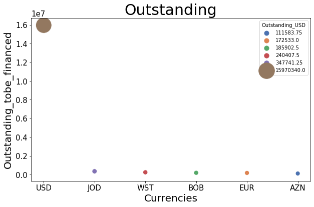

```python
fig, ax = plt.subplots(figsize=(10, 6))

sns.scatterplot(x=df_currencyusd['currency'],
                y=df_currencyusd['Outstanding_USD'],
                size = df_currencyusd['Outstanding_USD'],
                sizes=(80, 1000),
                legend="full",
                hue = df_currencyusd['Outstanding_USD'],
                palette='deep'
                )

plt.xlabel("Currencies", fontsize=20)
plt.ylabel("Outstanding_tobe_financed",fontsize=20)

ax.set_title('Outstanding', fontsize=30)
```